# Algoritmos Genéticos x Força Bruta para seleção de modelos de regressão

Author

Rodrigo Hermont Ozon

Published

September 11, 2023

```r
start_time <- Sys.time()
```

**Algoritmos Genéticos x Força Bruta para seleção de modelos**

O cerne de qualquer modelo de regressão ou classificação reside na sua capacidade de elucidar a relação entre uma variável dependente e um conjunto de variáveis independentes, frequentemente referidas como preditores. A seleção desses preditores é uma tarefa desafiadora, pois não é intuitivamente evidente quais são essenciais e em que quantidade devem ser incorporados ao modelo.

A relevância dessa seleção é amplificada pelo risco de overfitting — quando um modelo é excessivamente complexo, capturando o ruído ao invés das verdadeiras relações subjacentes nos dados. Inversamente, um modelo com poucos preditores pode sofrer de underfitting, falhando em capturar relações significativas e comprometendo o seu desempenho preditivo.

Diante desses desafios, o objetivo torna-se identificar o modelo ideal que emprega um conjunto ótimo de preditores — aqueles que maximizam a explicação da variável dependente sem sucumbir ao ruído dos dados. Este artigo explora o uso de algoritmos genéticos como uma ferramenta eficaz para alcançar tal feito, destacando suas vantagens em relação às técnicas de força bruta, que, embora precisas, são computacionalmente onerosas e muitas vezes impraticáveis. Demonstramos como os algoritmos genéticos podem ser uma estratégia superior para equilibrar a complexidade do modelo e a precisão preditiva, conduzindo a insights mais profundos e a modelos mais generalizáveis.

[figure not shown]

# Intro

A seleção de características é um passo crítico no processo de modelagem de regressão e classificação, pois influencia diretamente a performance e a eficiência do modelo final. Em contextos onde o número de características potenciais é vasto, a escolha de um método de seleção torna-se crucial. Tradicionalmente, poderíamos considerar a abordagem de força bruta, que testa todas as combinações possíveis de características para determinar o melhor conjunto. No entanto, essa estratégia é muitas vezes impraticável devido à sua complexidade exponencial, especialmente à medida que o número de características cresce. É aqui que os algoritmos genéticos (AGs) oferecem uma alternativa promissora.

Os algoritmos genéticos são inspirados nos processos de seleção natural e evolução biológica. Eles operam através da geração de uma população de soluções possíveis e, em seguida, aplicam operadores genéticos como seleção, cruzamento e mutação para evoluir as soluções ao longo de várias gerações. O objetivo é encontrar uma solução ótima ou satisfatória para o problema em questão.

Quando aplicados à seleção de características, os AGs têm várias vantagens sobre a abordagem de força bruta:

- **Eficiência Computacional:** Ao invés de avaliar todas as combinações possíveis, os AGs exploram o espaço de busca de maneira inteligente, focando nas soluções mais promissoras. Isso pode reduzir significativamente o tempo de computação necessário.
- **Flexibilidade:** Os AGs são capazes de lidar com espaços de busca não-lineares e com múltiplos ótimos locais, o que é comum em problemas de seleção de características.
- **Escalabilidade:** Eles são mais escaláveis em relação ao número de características, tornando-os adequados para datasets de alta dimensão.
- **Adaptabilidade:** Os AGs podem se adaptar a mudanças no espaço de busca, o que é útil em cenários onde os dados estão evoluindo.
- **Soluções Globais:** Enquanto a força bruta garante encontrar a solução ótima global, ela é muitas vezes inviável. Os AGs, embora não garantam a solução ótima global, têm uma boa chance de se aproximar dela ou encontrar soluções que sejam suficientemente boas.

Dentro do contexto da seleção de variáveis, os algoritmos genéticos desempenham um papel crucial na mitigação do sobreajuste, ou overfitting, um problema comum quando um modelo é excessivamente complexo.

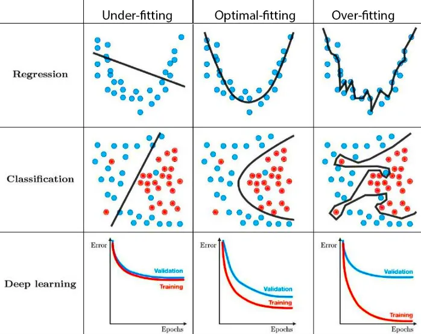

**Fonte:** [Minhas (2021)](https://towardsdatascience.com/techniques-for-handling-underfitting-and-overfitting-in-machine-learning-348daa2380b9)

Ao simular o processo de evolução natural para otimizar a seleção de características, os algoritmos genéticos buscam um equilíbrio entre a adequação do modelo aos dados e a sua generalização para dados não vistos. Eles fazem isso ao penalizar conjuntos de características que são muito grandes ou que não contribuem significativamente para o poder preditivo do modelo. Isso é comparável à seleção natural, onde apenas os traços mais adaptáveis são passados para a próxima geração. Ao aplicar essa abordagem iterativa e seletiva, os algoritmos genéticos evitam eficazmente a armadilha de modelar o ruído estatístico presente nos dados de treinamento, o que é uma causa comum de sobreajuste em modelos preditivos. Assim, eles ajudam a assegurar que o modelo final seja robusto e confiável, com uma capacidade aprimorada de generalizar bem para novos conjuntos de dados.

Em resumo, os algoritmos genéticos oferecem uma abordagem mais viável e eficiente para a seleção de características em modelos de regressão e classificação, especialmente quando confrontados com um grande número de características. Eles não apenas economizam recursos computacionais valiosos, mas também fornecem um meio robusto e adaptável para navegar pelo complexo processo de identificar as características mais significativas para a modelagem.

**R packages**

```r
library(dplyr)
library(tidyverse)
library(car)
library(MASS)
library(ISLR)
library(tictoc)
library(sjPlot)
library(glmulti)
library(flextable)
library(performance)

theme_set(theme_light(base_size = 12))  # Ajusta os temas dos gráficos
theme_update(panel.grid.minor = element_blank())
```

# Método StepWise e Força Bruta

**Método Stepwise**

A técnica stepwise é um método estatístico iterativo utilizado para selecionar um subconjunto ótimo de variáveis preditoras para um modelo estatístico, como regressão linear ou logística. Funciona através de um processo de seleção sequencial onde, em cada etapa, uma variável é adicionada ou removida do modelo baseado em critérios específicos, como o valor do teste F, o critério de informação de Akaike (AIC) ou o critério de informação bayesiano (BIC). Existem duas formas principais da técnica stepwise: a seleção para frente (forward selection), que começa com nenhum preditor e adiciona o mais significativo em cada passo, e a seleção para trás (backward elimination), que começa com todos os possíveis preditores e remove o menos significativo em cada etapa.

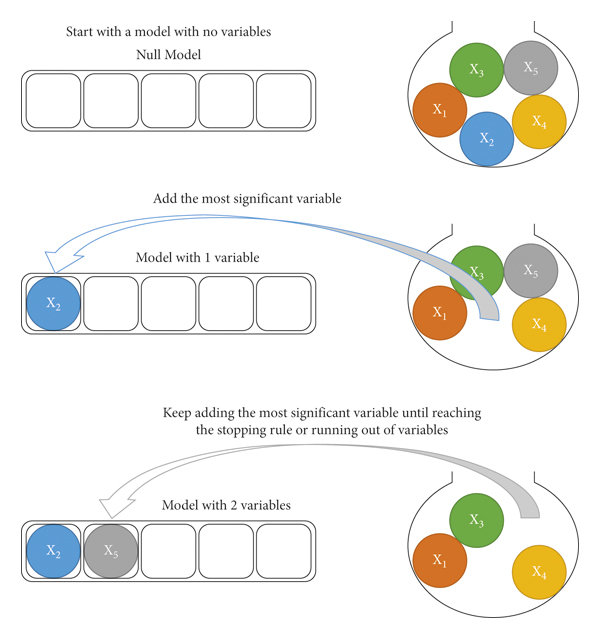

**Fonte:** Siddiqi *et. alli* (2022)

O processo continua até que nenhum novo preditor melhore significativamente o modelo ao ser adicionado ou removido, resultando em um modelo que se espera que tenha um bom equilíbrio entre a simplicidade e a capacidade preditiva.

Para exemplificar, utilizaremos aqui um conjunto de dados bastante conhecido:

```r
glimpse(mtcars)
```

```
Rows: 32
Columns: 11
$ mpg  <dbl> 21.0, 21.0, 22.8, 21.4, 18.7, 18.1, 14.3, 24.4, 22.8, 19.2, 17.8,…
$ cyl  <dbl> 6, 6, 4, 6, 8, 6, 8, 4, 4, 6, 6, 8, 8, 8, 8, 8, 8, 4, 4, 4, 4, 8,…
$ disp <dbl> 160.0, 160.0, 108.0, 258.0, 360.0, 225.0, 360.0, 146.7, 140.8, 16…
$ hp   <dbl> 110, 110, 93, 110, 175, 105, 245, 62, 95, 123, 123, 180, 180, 180…
$ drat <dbl> 3.90, 3.90, 3.85, 3.08, 3.15, 2.76, 3.21, 3.69, 3.92, 3.92, 3.92,…
$ wt   <dbl> 2.620, 2.875, 2.320, 3.215, 3.440, 3.460, 3.570, 3.190, 3.150, 3.…
$ qsec <dbl> 16.46, 17.02, 18.61, 19.44, 17.02, 20.22, 15.84, 20.00, 22.90, 18…
$ vs   <dbl> 0, 0, 1, 1, 0, 1, 0, 1, 1, 1, 1, 0, 0, 0, 0, 0, 0, 1, 1, 1, 1, 0,…
$ am   <dbl> 1, 1, 1, 0, 0, 0, 0, 0, 0, 0, 0, 0, 0, 0, 0, 0, 0, 1, 1, 1, 0, 0,…
$ gear <dbl> 4, 4, 4, 3, 3, 3, 3, 4, 4, 4, 4, 3, 3, 3, 3, 3, 3, 4, 4, 4, 3, 3,…
$ carb <dbl> 4, 4, 1, 1, 2, 1, 4, 2, 2, 4, 4, 3, 3, 3, 4, 4, 4, 1, 2, 1, 1, 2,…
```

```r
head(mtcars)
```

|  | mpg | cyl | disp | hp | drat | wt | qsec | vs | am | gear | carb |
| --- | --- | --- | --- | --- | --- | --- | --- | --- | --- | --- | --- |
| Mazda RX4 | 21.0 | 6 | 160 | 110 | 3.90 | 2.620 | 16.46 | 0 | 1 | 4 | 4 |
| Mazda RX4 Wag | 21.0 | 6 | 160 | 110 | 3.90 | 2.875 | 17.02 | 0 | 1 | 4 | 4 |
| Datsun 710 | 22.8 | 4 | 108 | 93 | 3.85 | 2.320 | 18.61 | 1 | 1 | 4 | 1 |
| Hornet 4 Drive | 21.4 | 6 | 258 | 110 | 3.08 | 3.215 | 19.44 | 1 | 0 | 3 | 1 |
| Hornet Sportabout | 18.7 | 8 | 360 | 175 | 3.15 | 3.440 | 17.02 | 0 | 0 | 3 | 2 |
| Valiant | 18.1 | 6 | 225 | 105 | 2.76 | 3.460 | 20.22 | 1 | 0 | 3 | 1 |

Se quisermos prever o consumo de combustível desses modelos de automóveis, (em mpg/milhas por galão) deveremos utilizar as combinações ideias das variáveis explicativas que melhor descreveriam tais relações:

- Set de modelos (completo e nulo)

```r
# Modelo completo e nulo
full_model <- glm(mpg ~ (hp + drat + wt + qsec + gear)^2,
                 data = mtcars, family = gaussian)

null_model <- glm(mpg ~ 1, data = mtcars, family = gaussian)
```

- Rodo o procedimento backward

```r
# Roda o procedimento backward
optimal_model_backward <- step(full_model, direction = "backward",
                        scope = list(upper = full_model, lower = null_model))
```

- Rodo o forward

```r
optimal_model_forward <- step(null_model, direction = "forward",
                        scope = list(upper = full_model, lower = null_model))
```

- Comparando o modelo escolhido pelo backward com o forward:
- Melhor backward

```r
summary(optimal_model_backward)
```

```
Call:
glm(formula = mpg ~ hp + drat + wt + qsec + gear + hp:drat +
    hp:wt + hp:qsec + hp:gear + drat:wt + drat:qsec + wt:qsec +
    wt:gear, family = gaussian, data = mtcars)

Deviance Residuals:
     Min        1Q    Median        3Q       Max
-2.51094  -0.94114  -0.04562   1.05155   2.50569

Coefficients:
              Estimate Std. Error t value Pr(>|t|)
(Intercept) -3.888e+02  1.425e+02  -2.728 0.013799 *
hp           5.447e-01  2.178e-01   2.501 0.022258 *
drat         2.668e+01  1.913e+01   1.395 0.180120
wt           8.225e+01  2.679e+01   3.070 0.006592 **
qsec         1.713e+01  6.236e+00   2.748 0.013234 *
gear         2.316e+01  5.420e+00   4.273 0.000457 ***
hp:drat     -1.236e-01  4.469e-02  -2.765 0.012748 *
hp:wt       -5.294e-02  2.488e-02  -2.128 0.047392 *
hp:qsec     -1.135e-02  6.886e-03  -1.649 0.116531
hp:gear      5.046e-02  2.181e-02   2.314 0.032709 *
drat:wt      5.970e+00  2.452e+00   2.435 0.025530 *
drat:qsec   -1.422e+00  9.779e-01  -1.454 0.163231
wt:qsec     -3.362e+00  1.082e+00  -3.107 0.006091 **
wt:gear     -9.950e+00  2.868e+00  -3.469 0.002738 **
---
Signif. codes:  0 '***' 0.001 '**' 0.01 '*' 0.05 '.' 0.1 ' ' 1

(Dispersion parameter for gaussian family taken to be 2.851113)

    Null deviance: 1126.05  on 31  degrees of freedom
Residual deviance:   51.32  on 18  degrees of freedom
AIC: 135.93

Number of Fisher Scoring iterations: 2
```

- Melhor forward

```r
summary(optimal_model_forward)
```

```
Call:
glm(formula = mpg ~ wt + hp + qsec + gear + wt:hp, family = gaussian,
    data = mtcars)

Deviance Residuals:
    Min       1Q   Median       3Q      Max
-2.9608  -1.2725  -0.5094   1.5570   4.3383

Coefficients:
             Estimate Std. Error t value Pr(>|t|)
(Intercept) 33.998432   8.706505   3.905 0.000599 ***
wt          -7.983387   1.356531  -5.885 3.31e-06 ***
hp          -0.107998   0.025782  -4.189 0.000285 ***
qsec         0.555013   0.355563   1.561 0.130629
gear         0.997389   0.691065   1.443 0.160887
wt:hp        0.027265   0.007165   3.805 0.000775 ***
---
Signif. codes:  0 '***' 0.001 '**' 0.01 '*' 0.05 '.' 0.1 ' ' 1

(Dispersion parameter for gaussian family taken to be 4.310122)

    Null deviance: 1126.05  on 31  degrees of freedom
Residual deviance:  112.06  on 26  degrees of freedom
AIC: 144.92

Number of Fisher Scoring iterations: 2
```

A seleção de variáveis utilizando o método stepwise é uma técnica amplamente adotada na busca pelo modelo mais eficaz. Contudo, apesar de sua popularidade, ela não é infalível. O método stepwise incorpora duas estratégias principais: a seleção progressiva (forward selection) e a seleção regressiva (backward elimination). No entanto, essa abordagem enfrenta desafios significativos. Um deles é a falta de convergência para um modelo consistente, pois as estratégias progressiva e regressiva podem resultar em modelos distintos, como ilustrado em nosso exemplo. Além disso, mesmo na eventual convergência para um modelo comum, não há garantia de que este seja o mais adequado. Essa limitação decorre da natureza incremental do método stepwise, que avalia os modelos adicionando ou removendo variáveis sequencialmente, sem considerar todas as combinações possíveis de variáveis simultaneamente. Este processo iterativo de comparação e seleção pode, portanto, negligenciar a configuração ideal de variáveis que maximizaria o desempenho do modelo.

Veja pelo teste de $\chi^2$ na ANOVA e da tabela de métricas de performance:

- $\chi^2$

```r
anova(optimal_model_backward, optimal_model_forward, test = "Chisq")
```

|  | Resid. Df | Resid. Dev | Df | Deviance | Pr(>Chi) |
| --- | --- | --- | --- | --- | --- |
| 1 | 18 | 51.32004 | NA | NA | NA |
| 2 | 26 | 112.06318 | -8 | -60.74314 | 0.006379731 |

- Tabela comparativa:

```r
compare_performance(optimal_model_backward, optimal_model_forward)
```

| Name | Model | AIC | AIC_wt | AICc | AICc_wt | BIC | BIC_wt | R2 | RMSE | Sigma |
| --- | --- | --- | --- | --- | --- | --- | --- | --- | --- | --- |
| optimal_model_backward | glm | 135.9271 | 0.98896627 | 165.9271 | 0.0002826657 | 157.9132 | 0.2030661 | 0.9544246 | 1.266393 | 1.688524 |
| optimal_model_forward | glm | 144.9185 | 0.01103373 | 149.5852 | 0.9997173343 | 155.1787 | 0.7969339 | 0.9004809 | 1.871356 | 2.076083 |

Aqui os critérios de informação (AIC, BIC) são preferíveis em relação ao R^2 por exemplo, pois eles demonstram melhor o ajuste do modelo, onde ele possa ser analisado/considerado como aquele de menor AIC/BIC como preferível, na medida em que o modelo for incorporando mais preditores (mais parâmetros então maior a chance de overfitting, p. ex. e menor, underfitting).

**Método Exaustivo (Força Bruta)**

Utilizando o pacote `glmulti` no ambiente de programação R, é viável implementar um método exaustivo que constrói todos os modelos estatísticos concebíveis, levando em conta todas as combinações de preditores e, se desejado, suas interações binárias. Esta técnica é conhecida como “força bruta”, refletindo sua abrangência e intensidade computacional.

O `glmulti` procede à avaliação comparativa dos modelos, baseando-se na quantidade de informação relevante que cada um oferece. Para tal, emprega-se critérios de informação, tais como o Critério de Informação de Akaike (AIC) ou o Critério de Informação Bayesiano (BIC). Esses critérios são preferidos em detrimento de métricas tradicionais como o R², pois oferecem uma medida de “adequação” do modelo que incorpora uma penalidade proporcional ao número de preditores utilizados.

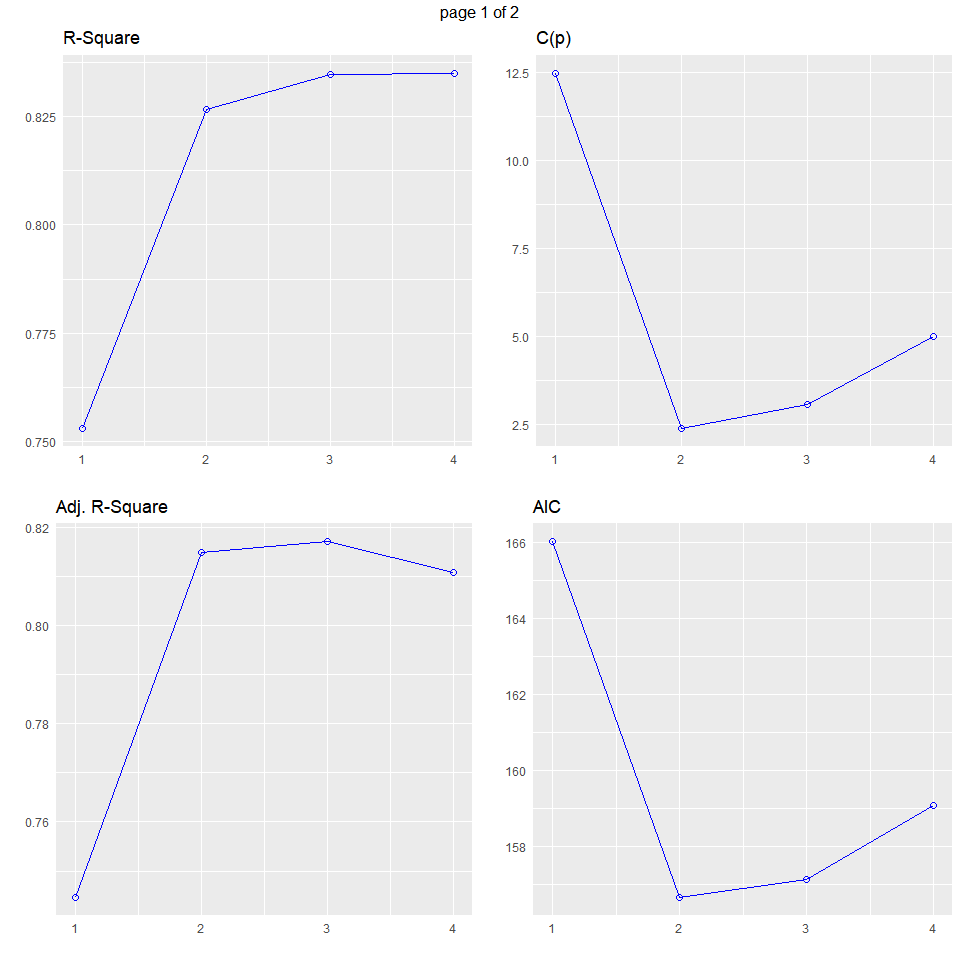

Fonte: [Hebbali (2020)](https://cran.r-project.org/web/packages/olsrr/vignettes/variable_selection.html)

Diferentemente dos critérios de informação, o R² tende a aumentar à medida que mais termos são adicionados ao modelo, o que pode levar a um sobreajuste. Um modelo sobreajustado é problemático, pois tende a refletir o ruído dos dados em vez de capturar as relações substanciais entre as variáveis. Isso torna os coeficientes estimados e os valores-p associados pouco confiáveis para inferências estatísticas.

O sobreajuste não apenas compromete a precisão do modelo, mas também sua aplicabilidade, pois um modelo que se ajusta demais às idiossincrasias de uma amostra específica falha em ser generalizável para outras amostras, reduzindo sua utilidade prática. Portanto, é essencial construir uma gama abrangente de modelos e utilizar Critérios de Informação para sua comparação, em vez de se fiar exclusivamente no R². Apesar da eficácia da abordagem de força bruta, o desafio reside na gestão do grande número de modelos potenciais, o que exige estratégias para otimizar o processo de seleção e análise, mantendo a integridade e a eficiência computacional.

Mudamos o nosso dataset (não mais o `mtcars`) e neste estudo, nosso foco é analisar o salário de 3.000 trabalhadores americanos, utilizando cinco variáveis preditoras: classe de trabalho, educação, idade, saúde e seguro de saúde. Para realizar essa análise, selecionamos o conjunto de dados “Wage”, disponível no pacote `ISLR` do ambiente estatístico R.

A escolha do Critério de Informação (CI) para avaliar os modelos é crucial. Por padrão, utilizamos o Critério de Informação de Akaike (AIC), mas temos à disposição outras opções como o Critério de Informação Bayesiano (BIC), o quasi-AIC para dados com superdispersão ou de contagem (qaic e qaicc), e o AIC corrigido para amostras pequenas (aicc). Este último é de minha preferência pessoal, pois oferece resultados consistentes com o AIC em amostras grandes e supera seu desempenho em amostras menores, proporcionando uma avaliação mais precisa em contextos com limitações de dados. Essa flexibilidade na escolha do CI permite uma adaptação mais fina à natureza dos dados e aos objetivos específicos da análise, garantindo que a seleção do modelo seja tanto rigorosa quanto relevante para a interpretação dos fatores que influenciam os salários no mercado de trabalho americano.

Veremos até quantos candidatos a modelos possíveis rodando a rotina presente no pacote `glmulti`. O argumento `method = "d"` conta o número de modelos candidatos sem realizar nenhum cálculo. Para o nosso exemplo com 5 preditores, teremos 32 modelos sem interações e 1921 modelos com interações. Se o `method = "h"`, uma triagem exaustiva é realizada, o que significa que todos os modelos possíveis serão criados. Se o `method = "g"`, o algoritmo genético é empregado (recomendado para grandes conjuntos de candidatos).

- Possibilidades de Modelos sem as interações

```r
glmulti(wage   ~ jobclass + education + age + health + health_ins,
        data   = Wage,
        crit   = aicc,       # AICC é o AIC corrigido para pequenas amostras
        level  = 1,          # 2 com interações, 1 sem
        method = "d",        # "d", ou "h", ou "g"
        family = gaussian,
        fitfunction = glm,   # Tipo de modelo (LM, GLM etc.)
        confsetsize = 100)   # utiliza somente os 100 melhores modelos
```

```
Initialization...
TASK: Diagnostic of candidate set.
Sample size: 3000
4 factor(s).
1 covariate(s).
0 f exclusion(s).
0 c exclusion(s).
0 f:f exclusion(s).
0 c:c exclusion(s).
0 f:c exclusion(s).
Size constraints: min =  0 max = -1
Complexity constraints: min =  0 max = -1
Your candidate set contains 32 models.
```

```
[1] 32
```

- Possibilidades de Modelos com as interações

```r
glmulti(wage   ~ jobclass + education + age + health + health_ins,
        data   = Wage,
        crit   = aicc,       # AICC é o AIC corrigido para pequenas amostras
        level  = 2,          # 2 com interações, 1 sem
        method = "d",        # "d", ou "h", ou "g"
        family = gaussian,
        fitfunction = glm,   # Tipo de modelo (LM, GLM etc.)
        confsetsize = 100)   # utiliza somente os 100 melhores modelos
```

```
Initialization...
TASK: Diagnostic of candidate set.
Sample size: 3000
4 factor(s).
1 covariate(s).
0 f exclusion(s).
0 c exclusion(s).
0 f:f exclusion(s).
0 c:c exclusion(s).
0 f:c exclusion(s).
Size constraints: min =  0 max = -1
Complexity constraints: min =  0 max = -1
Your candidate set contains 1921 models.
```

```
[1] 1921
```

Veja que dispomos de 32 modelos válidos sem interações entre as explicativas e 1921 com as interações entre elas.

Procederemos agora à execução do algoritmo exaustivo para calcular 1921 regressões, com o objetivo de identificar o modelo ótimo que integra as interações entre os cinco preditores selecionados. Para monitorar o tempo de processamento, utilizaremos as funções de contagem de tempo do pacote `tictoc`.

```
Initialization...
TASK: Exhaustive screening of candidate set.
Fitting...

After 50 models:
Best model: wage~1+education+age+jobclass:age+health:age+health_ins:age
Crit= 29827.864295308
Mean crit= 30184.7335535017
```

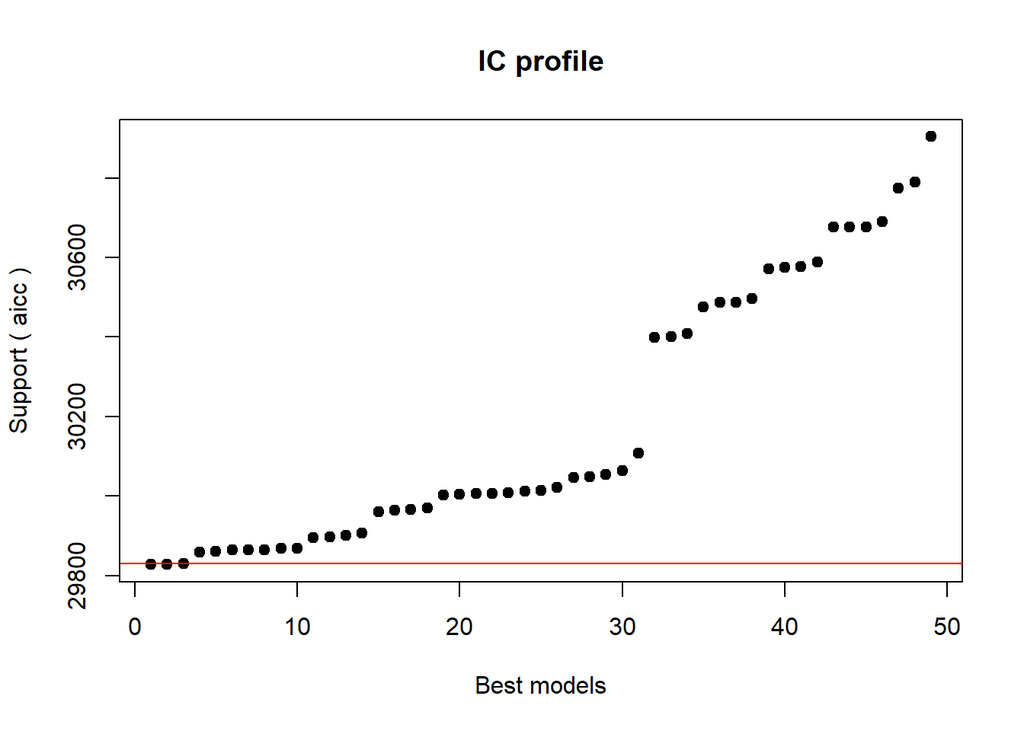

```
After 100 models:
Best model: wage~1+jobclass+education+age+education:jobclass+education:age+health:age+health_ins:age
Crit= 29815.9273144544
Mean crit= 30114.5541058805
```

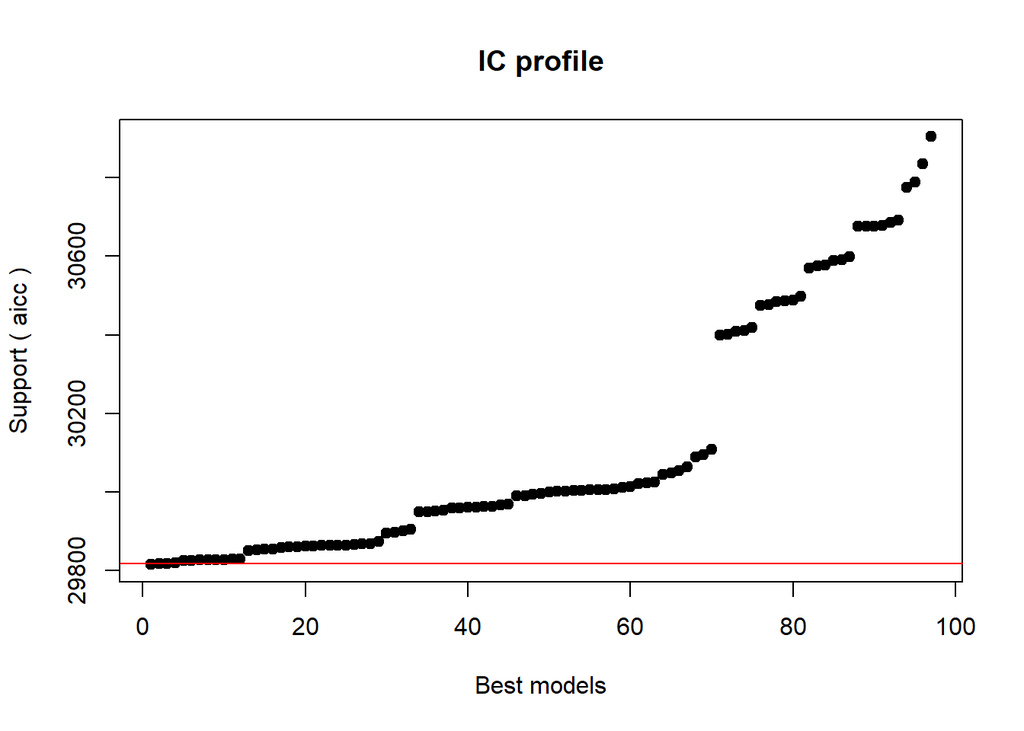

```
After 150 models:
Best model: wage~1+jobclass+education+age+education:jobclass+education:age+health:age+health_ins:age
Crit= 29815.9273144544
Mean crit= 29934.7534975215
```

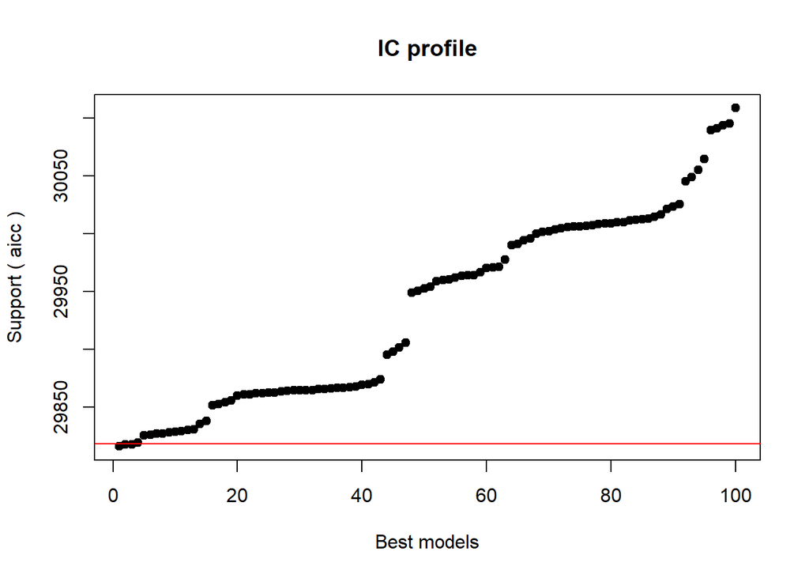

```
After 200 models:
Best model: wage~1+jobclass+education+age+education:jobclass+education:age+health:age+health_ins:age
Crit= 29815.9273144544
Mean crit= 29885.0804095925
```

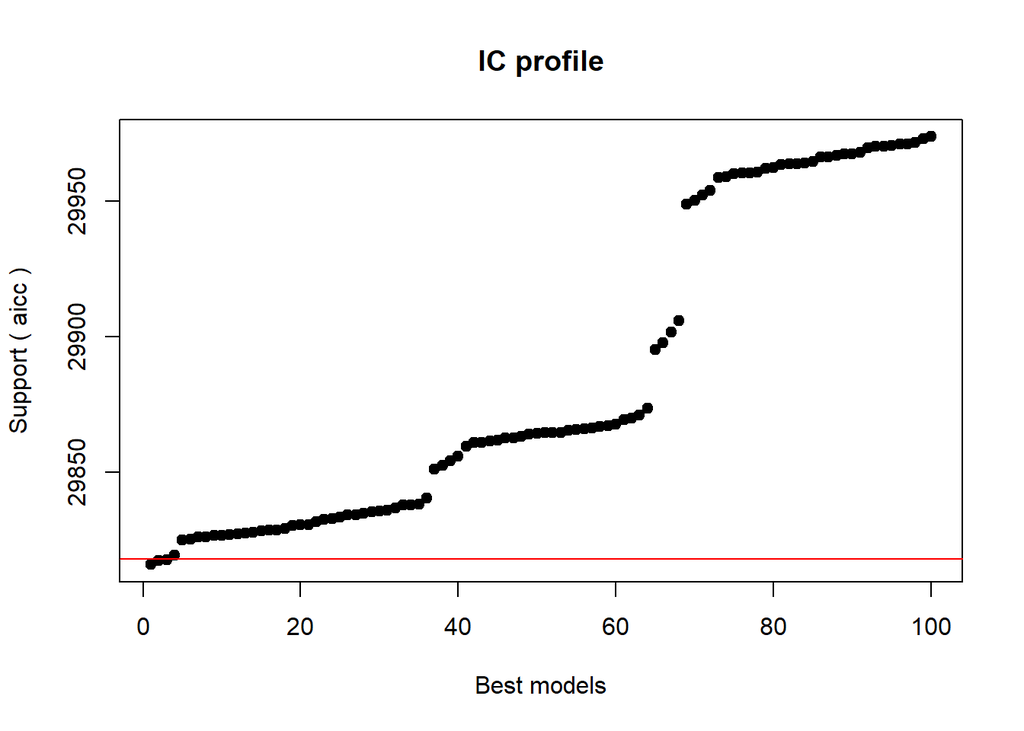

```
After 250 models:
Best model: wage~1+jobclass+education+age+education:jobclass+education:age+health:age+health_ins:age
Crit= 29815.9273144544
Mean crit= 29853.1589383865
```

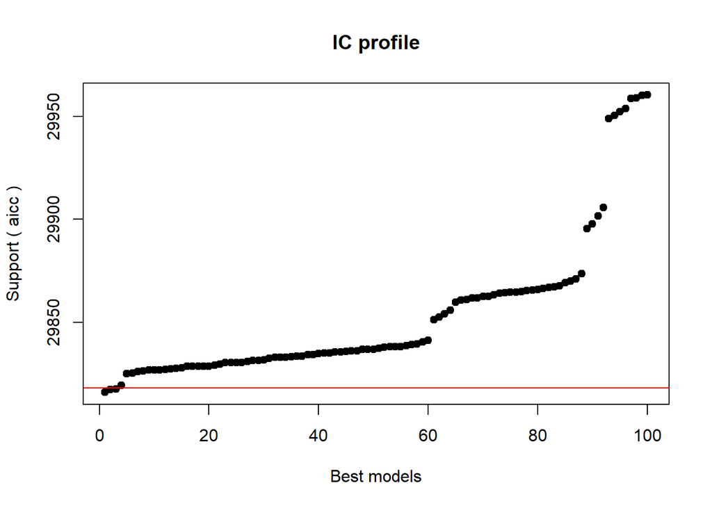

```
After 300 models:
Best model: wage~1+jobclass+education+health+age+education:jobclass+education:age+health:age+health_ins:age
Crit= 29815.7251202986
Mean crit= 29834.13579651
```

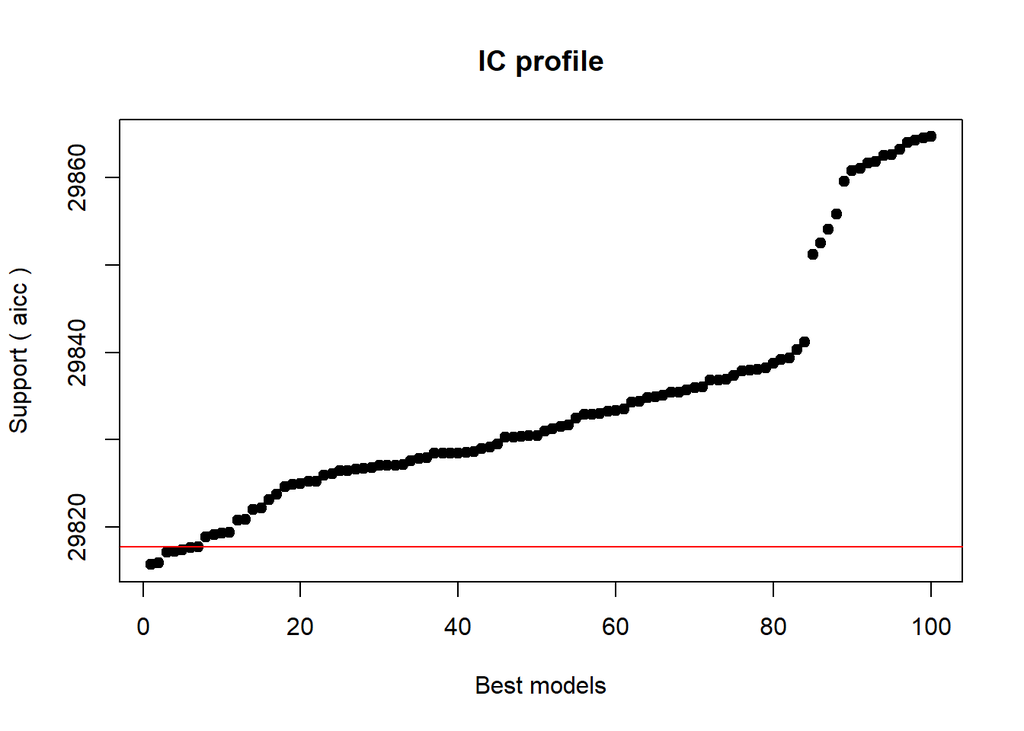

```
After 350 models:
Best model: wage~1+jobclass+education+health+age+education:jobclass+education:age+health:age+health_ins:age
Crit= 29815.7251202986
Mean crit= 29829.7529704456
```

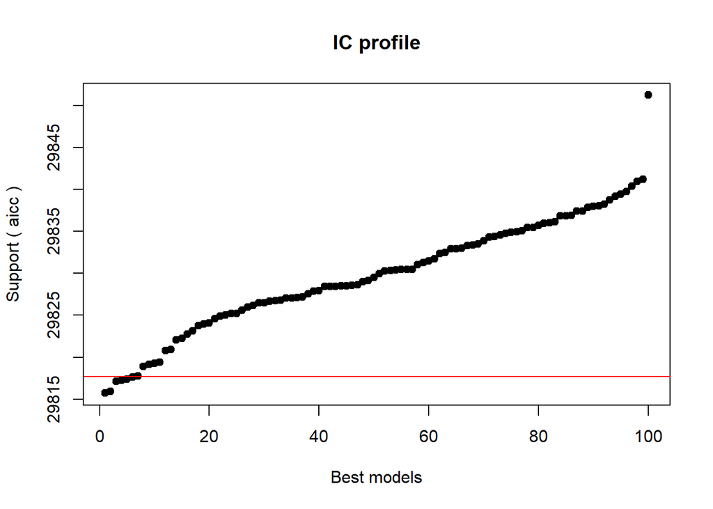

```
After 400 models:
Best model: wage~1+education+health_ins+age+health_ins:education+education:age+health:age
Crit= 29805.2622191833
Mean crit= 29825.4446546592
```

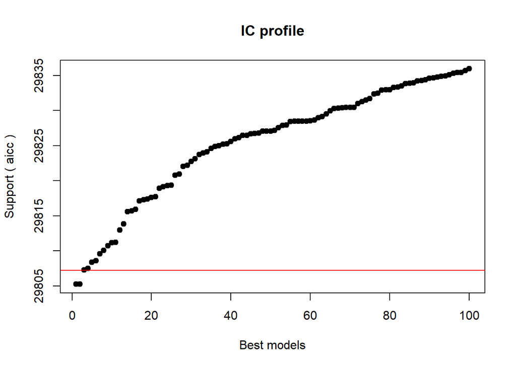

```
After 450 models:
Best model: wage~1+education+health_ins+age+health_ins:education+jobclass:age+education:age+health:age+health_ins:age
Crit= 29803.0289240545
Mean crit= 29820.4943030812
```

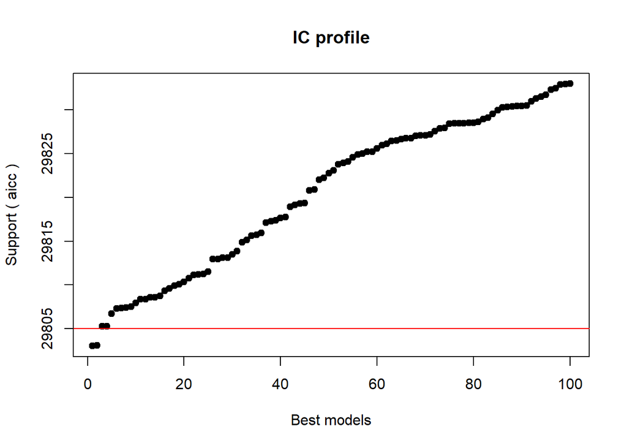

```
After 500 models:
Best model: wage~1+jobclass+education+health_ins+age+education:jobclass+education:age+health:age
Crit= 29796.7544660965
Mean crit= 29814.2488044282
```

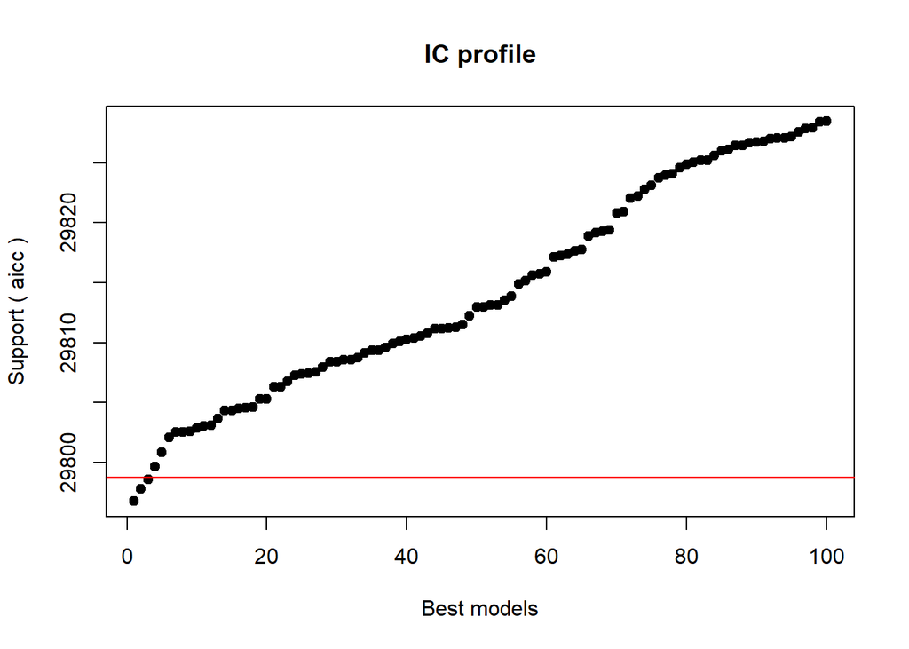

```
After 550 models:
Best model: wage~1+jobclass+education+health_ins+age+education:jobclass+health_ins:education+education:age+health:age
Crit= 29794.403562754
Mean crit= 29808.3093463257
```

```
After 600 models:
Best model: wage~1+jobclass+education+health_ins+age+education:jobclass+health_ins:education+education:age+health:age
Crit= 29794.403562754
Mean crit= 29808.3093463257
```

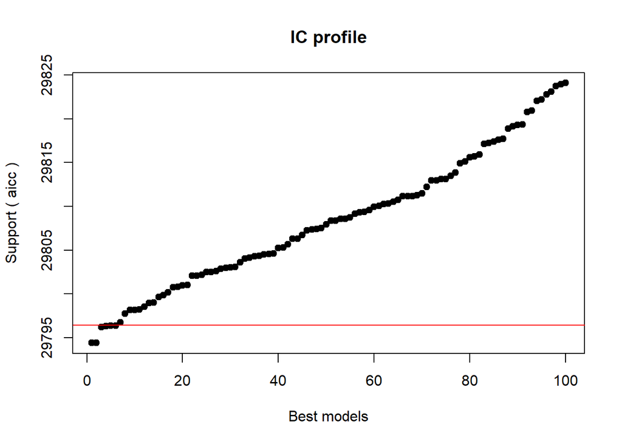

```
After 650 models:
Best model: wage~1+jobclass+education+health_ins+age+education:jobclass+health_ins:education+education:age+health:age
Crit= 29794.403562754
Mean crit= 29808.3093463257
```

```
After 700 models:
Best model: wage~1+jobclass+education+health_ins+age+education:jobclass+health_ins:education+education:age+health:age
Crit= 29794.403562754
Mean crit= 29808.3093463257
```

```
After 750 models:
Best model: wage~1+jobclass+education+health_ins+age+education:jobclass+health_ins:education+education:age+health:age
Crit= 29794.403562754
Mean crit= 29806.9777994778
```

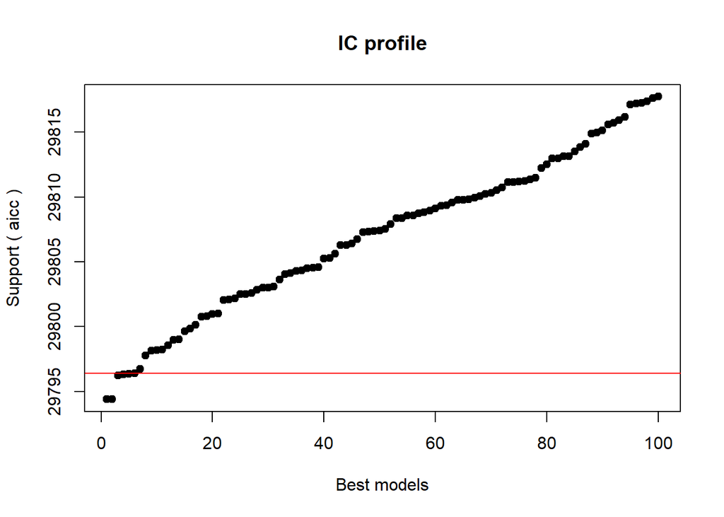

```
After 800 models:
Best model: wage~1+jobclass+education+health_ins+age+education:jobclass+health_ins:education+education:age+health:age
Crit= 29794.403562754
Mean crit= 29805.3845834103
```

[19 more figures not shown]

[output not shown]

```
Completed.
```

```r
tic()

h_model <- glmulti(wage ~ jobclass + education + age + health + health_ins,
          data   = Wage,
          crit   = aicc,
          level  = 2,
          method = "h",
          family = gaussian,
          fitfunction = glm,
          confsetsize = 100)
```

```r
toc() # 19 sec elapsed: 1921 models
```

```
24.23 sec elapsed
```

# Técnicas de melhoria de desempenho

**Remover termos desnecessários**

A estratégia inicial para aprimorar o desempenho consiste na eliminação de preditores ou interações que sejam redundantes. Tomemos, por exemplo, o peso e o índice de massa corporal (IMC), que tendem a fornecer informações sobrepostas — em termos estatísticos, diríamos que apresentam alta multicolinearidade. A inclusão simultânea de ambos os termos pode inflar desnecessariamente a quantidade de modelos possíveis, sem agregar valor significativo à análise.

Ilustrativamente, a adição de apenas dois preditores categóricos adicionais — estado civil (`maritl`) e região (`region`) — ao modelo salarial previamente mencionado, eleva o número de modelos potenciais para mais de 2,5 milhões (exatamente 2.604.485).

```r
glmulti(wage ~ jobclass + education + age + health + health_ins + maritl + region,
        data   = Wage,
        crit   = aicc,
        level  = 2,
        method = "d",
        family = gaussian,
        fitfunction = glm,
        confsetsize = 100,
        plotty=FALSE)
```

```
Initialization...
TASK: Diagnostic of candidate set.
Sample size: 3000
6 factor(s).
1 covariate(s).
0 f exclusion(s).
0 c exclusion(s).
0 f:f exclusion(s).
0 c:c exclusion(s).
0 f:c exclusion(s).
Size constraints: min =  0 max = -1
Complexity constraints: min =  0 max = -1
Your candidate set contains 2604485 models.
```

```
[1] 2604485
```

Diante de um volume tão elevado, que excede a capacidade de processamento convencional, o algoritmo genético surge como uma solução viável, capaz de navegar por este vasto espaço de modelos de maneira eficiente.

**Algoritmos Genéticos para Otimização**

Vamos comparar os timings com o nosso primeiro dataset de exemplo, o `mtcars`:

### Método Exaustivo

```
Initialization...
TASK: Exhaustive screening of candidate set.
Fitting...

After 50 models:
Best model: mpg~1+gear:wt+gear:qsec
Crit= 146.193186152864
Mean crit= 168.372599842419
```

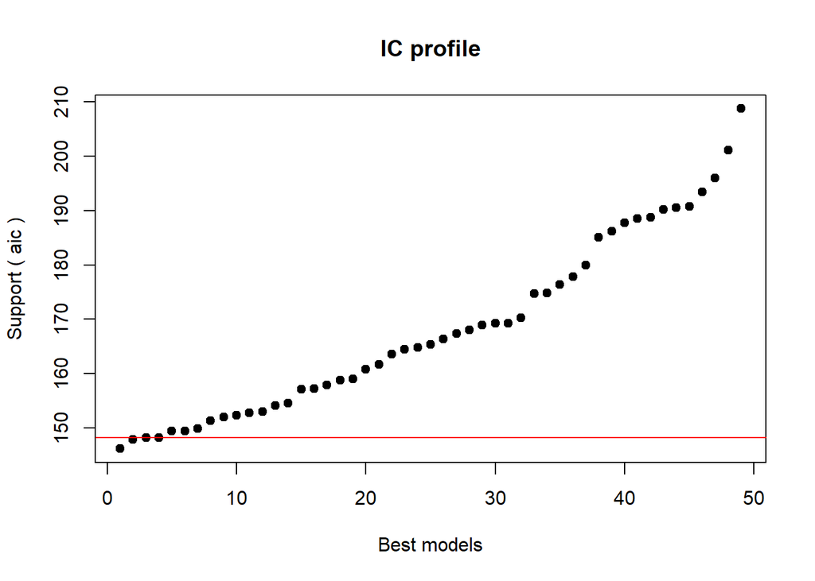

```
After 100 models:
Best model: mpg~1+gear:wt+gear:qsec
Crit= 146.193186152864
Mean crit= 163.894646890807
```

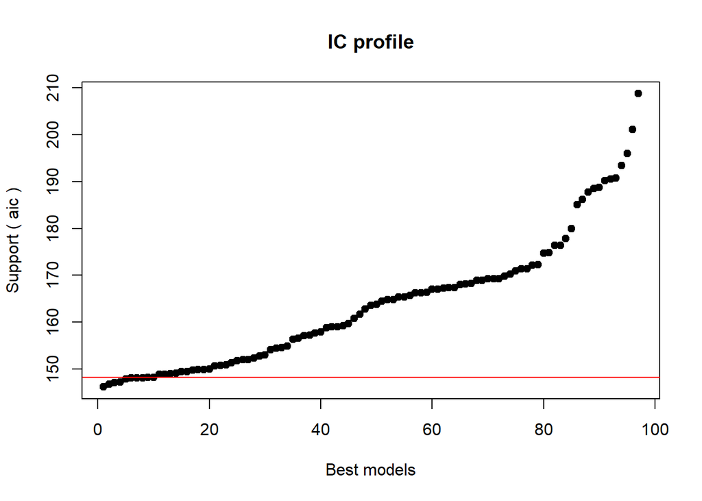

```
After 150 models:
Best model: mpg~1+drat:hp+wt:hp+qsec:wt+gear:wt+gear:qsec
Crit= 144.598329266555
Mean crit= 156.275404945991
```

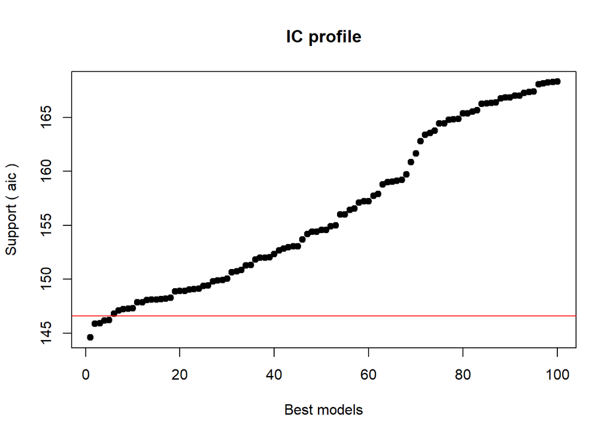

```
After 200 models:
Best model: mpg~1+drat:hp+wt:hp+qsec:wt+gear:wt+gear:qsec
Crit= 144.598329266555
Mean crit= 152.132216200647
```

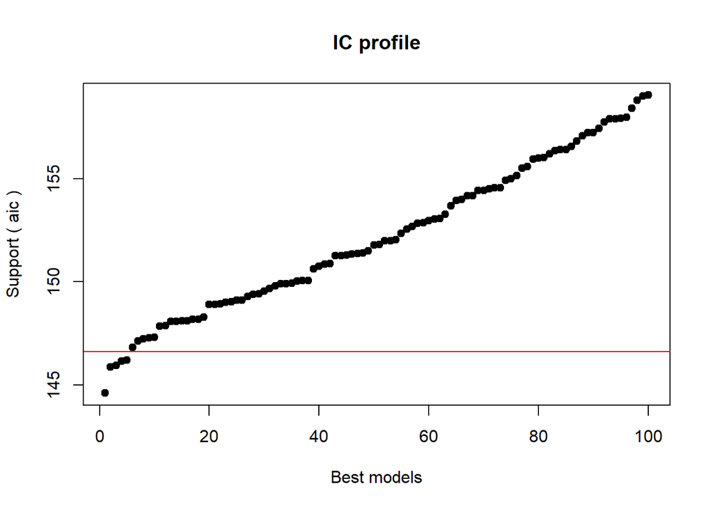

```
After 250 models:
Best model: mpg~1+drat:hp+wt:hp+qsec:wt+gear:wt+gear:qsec
Crit= 144.598329266555
Mean crit= 151.033663189397
```

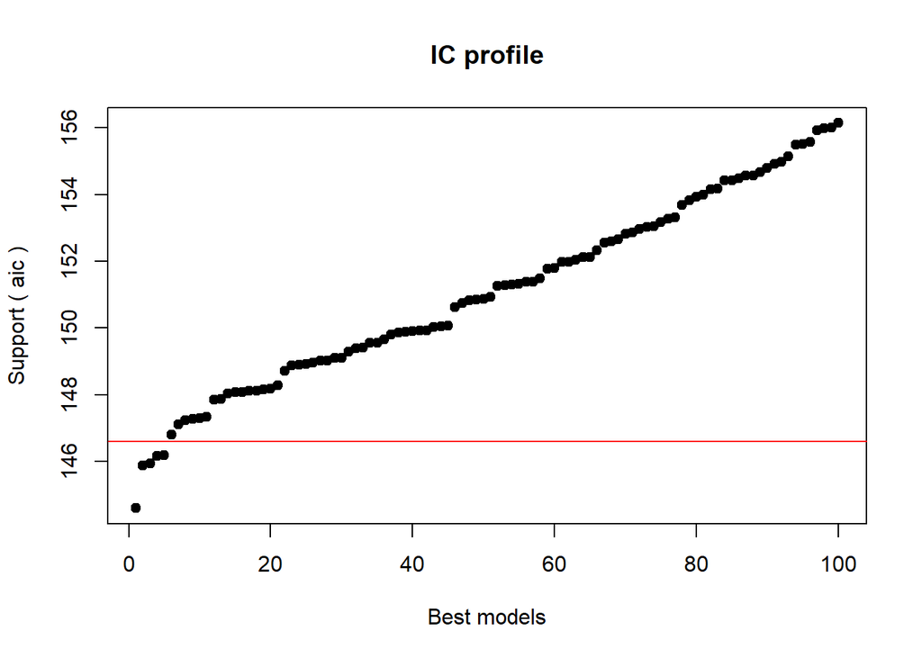

```
After 300 models:
Best model: mpg~1+drat:hp+wt:hp+qsec:wt+gear:wt+gear:qsec
Crit= 144.598329266555
Mean crit= 149.891456335748
```

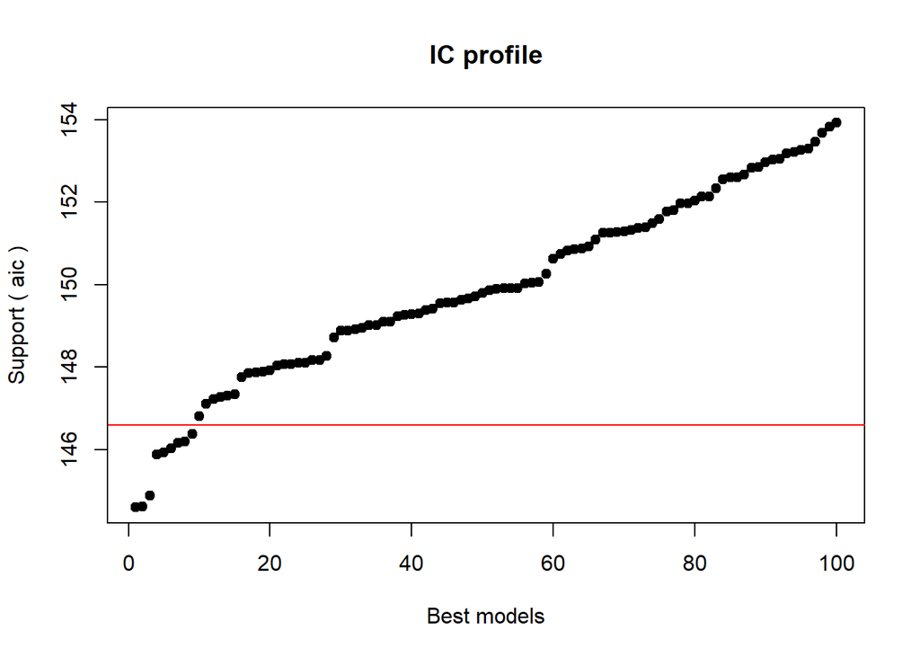

```
After 350 models:
Best model: mpg~1+drat:hp+wt:hp+qsec:wt+gear:wt+gear:qsec
Crit= 144.598329266555
Mean crit= 149.767066238731
```

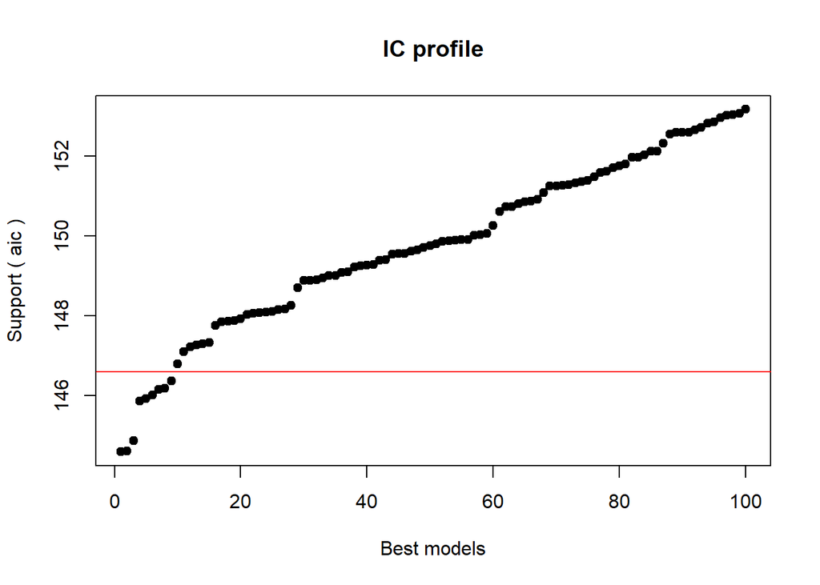

```
After 400 models:
Best model: mpg~1+wt:hp+qsec:hp+gear:hp+gear:wt+gear:qsec
Crit= 140.628643020179
Mean crit= 148.046431384816
```

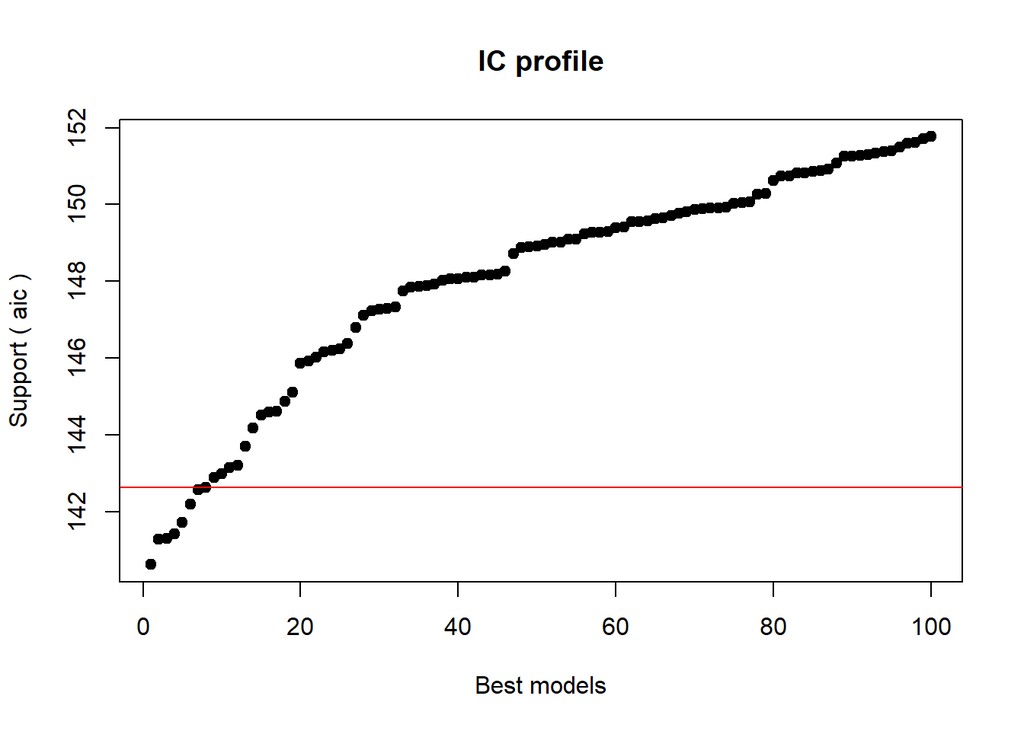

```
After 450 models:
Best model: mpg~1+wt:hp+qsec:hp+gear:hp+gear:wt+gear:qsec
Crit= 140.628643020179
Mean crit= 148.016745111225
```

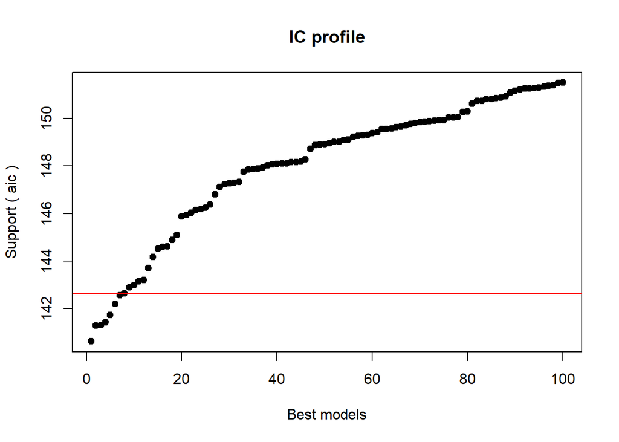

```
After 500 models:
Best model: mpg~1+wt:hp+qsec:hp+gear:hp+gear:wt+gear:qsec
Crit= 140.628643020179
Mean crit= 147.3045629641
```

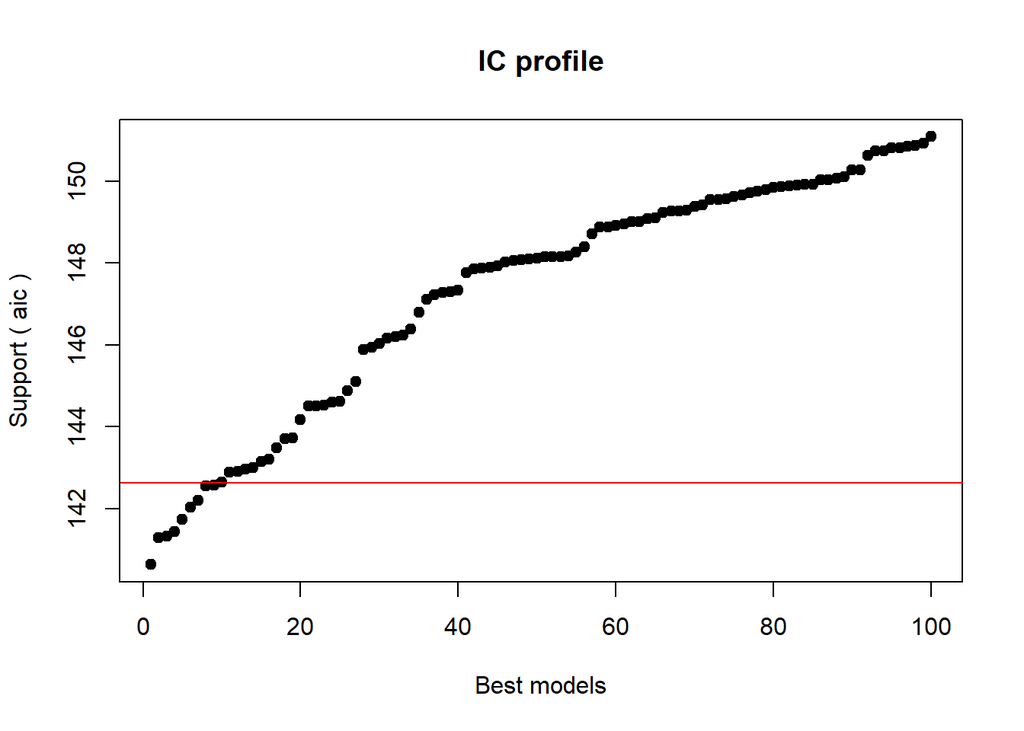

```
After 550 models:
Best model: mpg~1+wt:hp+qsec:hp+gear:hp+gear:wt+gear:qsec
Crit= 140.628643020179
Mean crit= 146.774135351077
```

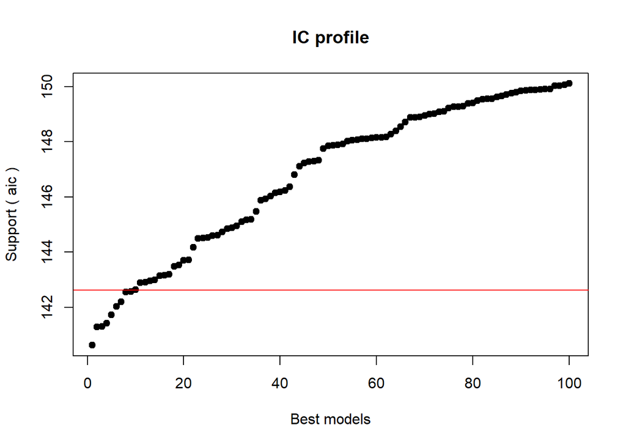

```
After 600 models:
Best model: mpg~1+wt:hp+qsec:hp+gear:hp+gear:wt+gear:qsec
Crit= 140.628643020179
Mean crit= 146.74082023953
```

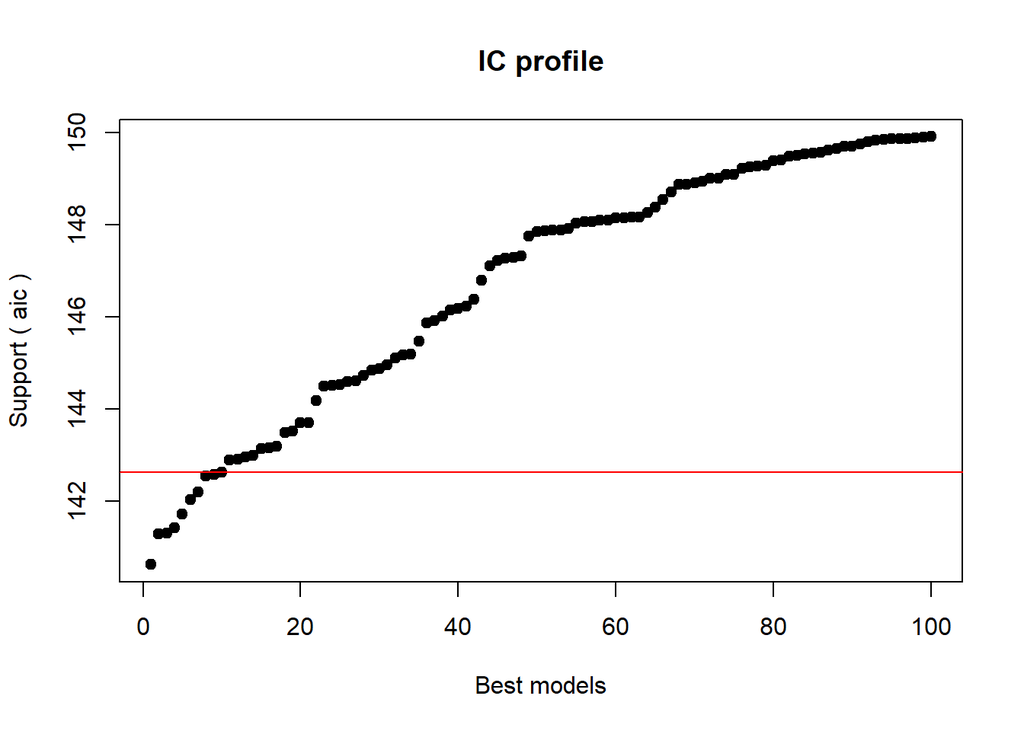

```
After 650 models:
Best model: mpg~1+wt:hp+qsec:hp+gear:hp+gear:wt+gear:qsec
Crit= 140.628643020179
Mean crit= 146.655123900789
```

[194 more figures not shown]

```
Completed.
```

```r
tic()

test_h <- glmulti(mpg ~ hp + drat + wt + qsec + gear,
                 data   = mtcars,
                 method = "h",       # h = método exaustivo (força bruta)
                 crit   = aic,
                 level  = 2,
                 family = gaussian,
                 fitfunction = glm,
                 confsetsize = 100)
```

```r
toc()
```

```
124.96 sec elapsed
```